# **Task 3 - Neural Networks - MS4H20**

This section uses Amazon Sagemaker in AWS to create and train a series of simple and convolutional neural networks. The code below imports all the packages used in this task.

```python
import boto3
import os
import torch
import torch.nn as nn
import torch.nn.functional as F
from torch.utils.data import DataLoader, TensorDataset
from sklearn.model_selection import train_test_split
from tqdm import tqdm
import torchvision
import numpy as np
import matplotlib.pyplot as plt
import seaborn as sns
from sklearn.metrics import confusion_matrix
```

After importing the libraries, code is run that checks for the presence of a GPU, and uses it if one is available. As a gpu is available in this notebook instance, it will be used where required in this notebook.

```python
if torch.cuda.is_available(): # Check if cuda is available
    device = torch.device("cuda:0") # Use GPU if available
    print("running on the GPU")
else:
    device = torch.device("cpu") # Use CPU if no GPU is available
    print("running on the CPU")
```

```
running on the GPU
```

## Part 1 - Question 1

"Create an S3 Bucket to store the dataset provided on the AWS Cloud"

The code below defines a function that downloads the data from the s3 bucket created in AWS, where the dataset has been stored. The code then defines a function that loads the data into the notebook as image_data and corresponding label_data

```python
# Downloads Dataset from s3 bucket:
def download_data_from_s3(bucket_name, images_file, labels_file):
    s3 = boto3.resource('s3')
    bucket = s3.Bucket(bucket_name)

    if not os.path.isfile(images_file):
        bucket.download_file(images_file, images_file)
    if not os.path.isfile(labels_file):
        bucket.download_file(labels_file, labels_file)

# Loads Dataset as image_data and corresponding label_data
def load_data(images_file, labels_file):
    image_data = torch.load(images_file)
    label_data = torch.load(labels_file)
    return image_data, label_data
```

The functions are then used to download the data from the bucket and load it into the notebook instance

```python
# Download dataset from s3 bucket
download_data_from_s3("harry-parrett-s3-live-bucket", "COVID_Mask_Images.pt", "COVID_Mask_Labels.pt")
```

When loading the data, the shape is viewed to see that there are 8982 images with 3 colour channels (RGB)

```python
# Load dataset into notebook and check shape
image_data, label_data = load_data('COVID_Mask_Images.pt', 'COVID_Mask_Labels.pt')
image_data.shape
```

```
torch.Size([8982, 3, 128, 128])
```

To quickly view the data. A random image has been selected to be viewed. This image has a label of 0, meaning they are wearing a mask but incorrectly. The other labels in this dataset are, 1 meaning they are wearing a mask correctly, and 2 meaning they are not wearing a mask at all

```
The Corrosponding Label is: 0
```

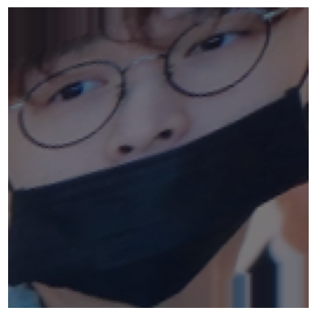

```python
# View a sample from the image data and check its corresponding label
sample_num = 5
print(f'The Corrosponding Label is: {label_data[sample_num]}')
image_vis = image_data[sample_num]
plt.imshow(image_vis.permute(1, 2, 0))
plt.axis('off')  # Turn off axes
plt.show()
```

## Part 1 - Question 2a - Basic Simple Neural Network

This section builds as simple neural network, without improving it. The focus is on constructing the model, without optimising performance. Later, an improved version will be created.

The first step is to split the data into a test set and a training set. The data is then flattened to be used in the model.

```python
# Split the data into test and train sets
train_images, test_images, train_labels, test_labels = train_test_split(image_data, label_data, test_size=0.2, random_state=42)

# Define a class that flattens the data
class Flatten(nn.Module):
    def forward(self, x):
        return x.view(x.size(0), -1)

# Call an instance of the flattening class
flattening_model = Flatten()

# Apply the flattening to image data
train_images = flattening_model(train_images)
test_images = flattening_model(test_images)

# Check flattened data shape
print("Flattened Train Shape:", train_images.shape)
print("Flattened Test Data Shape:", test_images.shape)
```

```
Flattened Train Shape: torch.Size([7185, 49152])
Flattened Test Data Shape: torch.Size([1797, 49152])
```

Then the simple neural network itself has been constructed. This model has 4 fully connected layers, going from the number of features, down to the number of classes. Between each layer the relu activation function has been used, with log_softmax used at the end. No optimisation has been done to the number of layers, or nodes within each layer.

```python
# A simple neural network model
class Simple_NN(nn.Module):
    # Initialising the model
    def __init__(self, n_features, n_classes):
        super(Simple_NN, self).__init__()
        self.flatten = Flatten()
        self.fc1 = nn.Linear(n_features, 2) # Defining each fully connected layer
        self.fc2 = nn.Linear(2, 100)
        self.fc3 = nn.Linear(100, 50)
        self.fc4 = nn.Linear(50, n_classes)

    # The feedforward process of the neural network
    def forward(self, x):
        x = self.flatten(x)
        x = F.relu(self.fc1(x))
        x = F.relu(self.fc2(x))
        x = F.relu(self.fc3(x))
        x = F.log_softmax(self.fc4(x), dim=1)
        return x
```

```python
# Set the number of features and number of classes.
n_features = train_images.size(1)
n_classes = 3
net = Simple_NN(n_features=n_features, n_classes=n_classes)
net.to(device)
```

```
Simple_NN(
  (flatten): Flatten()
  (fc1): Linear(in_features=49152, out_features=2, bias=True)
  (fc2): Linear(in_features=2, out_features=100, bias=True)
  (fc3): Linear(in_features=100, out_features=50, bias=True)
  (fc4): Linear(in_features=50, out_features=3, bias=True)
)
```

Next, the model is trained using cross entropy loss function and the SGD optimiser. 100 batches and 10 epochs have been used as placeholder values that will be tuned when creating the improved model.

```python
# Data Loaders
train_dataset = TensorDataset(train_images, train_labels)
train_loader = DataLoader(train_dataset, batch_size=100, shuffle=True)
```

```python
# Training Loop
loss_function = nn.CrossEntropyLoss() # Set the loss function
optimizer = torch.optim.SGD(net.parameters(), lr=0.01) # Set the optimiser
epochs = 10 # Set the number of epochs

# Run the training loop
for epoch in range(epochs):
    net.train()
    for batch_data, batch_labels in tqdm(train_loader):
        batch_data, batch_labels = batch_data.to(device), batch_labels.to(device)
        optimizer.zero_grad()
        output = net(batch_data)
        loss = loss_function(output, batch_labels)
        loss.backward()
        optimizer.step()

    print("Epoch {} Loss: {:.4f}".format(epoch + 1, loss.item()))
```

```
Epoch 1 Loss: 1.0205
```

```
Epoch 2 Loss: 0.6982
```

```
Epoch 3 Loss: 0.4763
```

```
Epoch 4 Loss: 0.5079
```

```
Epoch 5 Loss: 0.5142
```

```
Epoch 6 Loss: 0.4269
```

```
Epoch 7 Loss: 0.5795
```

```
Epoch 8 Loss: 0.4374
```

```
Epoch 9 Loss: 0.3033
```

```
Epoch 10 Loss: 0.2458
```

Once the training has been conducted, the model is then evaluated using the test set and an accuracy score is calculated. Here, an accuracy of 86% was achieved. At face value that seems like a good score, however cross validation has not been used. I have ran this model many times, and the accuracy varies a lot between as low as 0.3 to as high as 0.9. The average seemed to be around 0.7, so 70% accuracy is a more accurate figure overall. This performance will likely be greatly improved when improving the model later on.

```python
# Evaluation
net.eval()
with torch.no_grad():
    predicted = net(test_images.to(device))
    predicted_classes = torch.argmax(predicted, dim=1)

predicted_classes = predicted_classes.cpu()
test_labels = test_labels.cpu()

correct = (predicted_classes == test_labels).sum().item()
total = test_labels.size(0)
accuracy = correct / total
print("Accuracy: {:.3f}".format(accuracy))
```

```
Accuracy: 0.859
```

A confusion matrix is then created to show where the model performs the best, and worst. It seems that the model does the best at predicting class 2, those who are not wearing a mask at all, whilst it does slightly worse at predicting classes 0 and 1, where a mask is worn incorrectly and correctly.

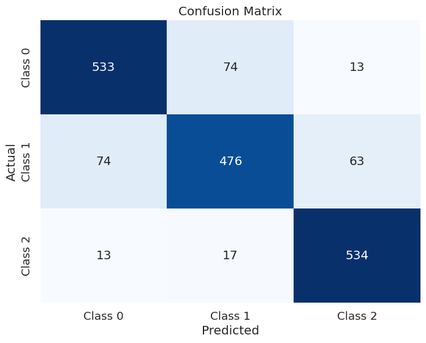

```python
# Compute confusion matrix
cf_mat = confusion_matrix(test_labels, predicted_classes)

# Create a figure and axis
plt.figure(figsize=(8, 6))
sns.set(font_scale=1.2)  # Adjust font size for better readability

# Create a heatmap for the confusion matrix
sns.heatmap(cf_mat, annot=True, fmt='d', cmap='Blues', cbar=False,
            xticklabels=['Class 0', 'Class 1', 'Class 2'],
            yticklabels=['Class 0', 'Class 1', 'Class 2'])

plt.xlabel('Predicted')
plt.ylabel('Actual')
plt.title('Confusion Matrix')
plt.show()
```

## Part 1 - Question 2a - Basic Convolutional Neural Network

In this section, a basic convolutional neural network is created and trained. Like before, performance is not focussed on here and an improved model will be created later. First, the data is reloaded just to ensure separation between sections.

```python
# Load the data
image_data, label_data = load_data('COVID_Mask_Images.pt', 'COVID_Mask_Labels.pt')
```

Then the data is split into a test and training set again.

```python
# Split data into test and train sets
train_images, test_images, train_labels, test_labels = train_test_split(image_data, label_data, test_size=0.2, random_state=42)
```

This time a convolutional neural network is created, which means the model contains convolutional layers. For this model, two convolutional layers are used, and after each convolutional layer, a self pooling layer is created.

```python
# A class for convolutional neural networks
class Conv_NN(nn.Module):
    def __init__(self, n_channels):
        super().__init__()

        # Defines the convolutional layers and the self pooling layer
        self.conv1 = nn.Conv2d(in_channels = n_channels, out_channels = 8, kernel_size = (5,5) )
        self.conv2 = nn.Conv2d(in_channels = 8, out_channels = 16,  kernel_size = (5,5))
        self.pool = nn.MaxPool2d((2,2))

        # Define the fully connected layers at the end of the neural network
        self.fc1 = nn.Linear(16*29*29, 128)
        self.fc2 = nn.Linear(128, 3)

        # Define the forward process
    def forward(self, x):
        x = F.relu(self.conv1(x))
        x = self.pool(x)

        x = F.relu(self.conv2(x))
        x = self.pool(x)

        # Flatten Data before fully connected layers
        x = x.view(-1, 16*29*29)

        #Fully Connected Layer
        x = F.relu(self.fc1(x))
        x = F.log_softmax(self.fc2(x), dim = 1)


        return x
```

As before, a version of this model is created with 3 channels representing the RGB colour channels.

```python
# Create instance of convoluted neural network model
net  = Conv_NN(n_channels = 3)
net.to(device)
```

```
Conv_NN(
  (conv1): Conv2d(3, 8, kernel_size=(5, 5), stride=(1, 1))
  (conv2): Conv2d(8, 16, kernel_size=(5, 5), stride=(1, 1))
  (pool): MaxPool2d(kernel_size=(2, 2), stride=(2, 2), padding=0, dilation=1, ceil_mode=False)
  (fc1): Linear(in_features=13456, out_features=128, bias=True)
  (fc2): Linear(in_features=128, out_features=3, bias=True)
)
```

This code was used to check the size at each stage of the process to help define the model.

```python
# Run the first image through the model and print its shape
input_images = train_images[0:1].to(device)
test = net.forward(input_images)
test.shape
```

```
torch.Size([1, 3])
```

The same loss function and optimizer as before have been used in training this model.

```python
# Define the loss function and optimizer to be used
loss_function = nn.CrossEntropyLoss()
optimizer = torch.optim.SGD(net.parameters(), lr=0.01)
```

```python
# Make sure the GPU is being used for model training
device = torch.device('cuda:0')
net.to(device)
```

```
Conv_NN(
  (conv1): Conv2d(3, 8, kernel_size=(5, 5), stride=(1, 1))
  (conv2): Conv2d(8, 16, kernel_size=(5, 5), stride=(1, 1))
  (pool): MaxPool2d(kernel_size=(2, 2), stride=(2, 2), padding=0, dilation=1, ceil_mode=False)
  (fc1): Linear(in_features=13456, out_features=128, bias=True)
  (fc2): Linear(in_features=128, out_features=3, bias=True)
)
```

The model is then trained using 10 epochs and a batch size of 100.

```python
# Set epochs and batch size then run training loop
epochs = 10
BATCH_SIZE = 100
for epoch in range (epochs):
    for i in tqdm(range(0,len(train_images), BATCH_SIZE)):
        # Batch Our Data
        batch_data = train_images[i:i+BATCH_SIZE]
        batch_labels = train_labels[i:i+BATCH_SIZE]
        batch_data = batch_data.to(device)
        batch_labels = batch_labels.to(device)


        net.zero_grad()  # sets gradients to 0 before loss calc
        output = net(batch_data)  # pass in the reshaped batch

        loss = loss_function(output, batch_labels)  # calc and grab the loss value
        loss.backward()  # apply this loss backwards through the network's parameters
        optimizer.step()  # attempt to optimize weights to account for loss/gradients

    print(loss)
```

```
tensor(1.2929, device='cuda:0', grad_fn=<NllLossBackward0>)
```

```
tensor(0.4829, device='cuda:0', grad_fn=<NllLossBackward0>)
```

```
tensor(0.4004, device='cuda:0', grad_fn=<NllLossBackward0>)
```

```
tensor(0.3534, device='cuda:0', grad_fn=<NllLossBackward0>)
```

```
tensor(0.3184, device='cuda:0', grad_fn=<NllLossBackward0>)
```

```
tensor(0.2905, device='cuda:0', grad_fn=<NllLossBackward0>)
```

```
tensor(0.2675, device='cuda:0', grad_fn=<NllLossBackward0>)
```

```
tensor(0.2502, device='cuda:0', grad_fn=<NllLossBackward0>)
```

```
tensor(0.2355, device='cuda:0', grad_fn=<NllLossBackward0>)
```

```
tensor(0.2260, device='cuda:0', grad_fn=<NllLossBackward0>)
```

The performance of the trained model is then calculated using the test set. The convoluted neural network had an accuracy of about 91%, which is higher than the 86% in the simple neural network. This performance was also much more robust. I ran the model many times and the performance varied significantly less than for the simple neural network.

```python
with torch.no_grad():
    predicted = net.forward(test_images.to(device))
    print(predicted[0:2], predicted[0:2].shape)

    # Pick  the class with highest value, and thus highest probability of being that number
    predicted_classes = torch.argmax(predicted, dim = 1)
    print(predicted_classes[0:5])
    print(test_labels[0:5])


device = torch.device('cpu')
predicted_classes = predicted_classes.to(device)
test_labels = test_labels.to(device)
```

```
tensor([[-9.5850e-02, -2.3930e+00, -1.0124e+01],
        [-1.2444e+01, -5.6612e+00, -3.4883e-03]], device='cuda:0') torch.Size([2, 3])
tensor([0, 2, 1, 2, 0], device='cuda:0')
tensor([0, 2, 1, 2, 1])
```

```python
correct = 0
total = 0
for i in range(len(predicted_classes)):

    if predicted_classes[i] == test_labels[i]:
        correct += 1
    total += 1
print("Accuracy: ", round(correct/total, 3))
```

```
Accuracy:  0.909
```

A confusion matrix is then created to assess the performance. It seems this model is much better at predicting class 0 than the simple neural network was, which is largely where the increase in accuracy has come from.

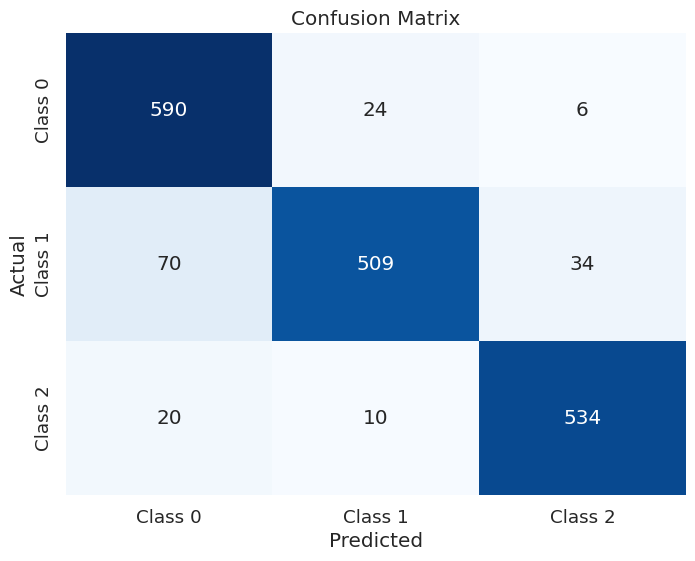

```python
# Compute confusion matrix
cf_mat = confusion_matrix(test_labels, predicted_classes)

# Create a figure and axis
plt.figure(figsize=(8, 6))
sns.set(font_scale=1.2)  # Adjust font size for better readability

# Create a heatmap for the confusion matrix
sns.heatmap(cf_mat, annot=True, fmt='d', cmap='Blues', cbar=False,
            xticklabels=['Class 0', 'Class 1', 'Class 2'],
            yticklabels=['Class 0', 'Class 1', 'Class 2'])

plt.xlabel('Predicted')
plt.ylabel('Actual')
plt.title('Confusion Matrix')
plt.show()
```

## Part 1 - Question 2b - Improved Simple Neural Network

This section takes the code from the simple neural network created earlier, and adapts it to make significant improvements to the model performance. The commentary for this section will outline all of the changes that have been made.

I increased batch size whilst decreasing learning rate. I added epochs. Changed SGD. Added new layers and used tanh

```python
# Load the data
image_data, label_data = load_data('COVID_Mask_Images.pt', 'COVID_Mask_Labels.pt')
image_data.shape
```

```
torch.Size([8982, 3, 128, 128])
```

```python
# Split the data into test and train sets
train_images, test_images, train_labels, test_labels = train_test_split(image_data, label_data, test_size=0.2, random_state=42)

class Flatten(nn.Module):
    def forward(self, x):
        return x.view(x.size(0), -1)

flattening_model = Flatten()

# Apply the flattening  to image data
train_images = flattening_model(train_images)
test_images = flattening_model(test_images)

print("Flattened Train Shape:", train_images.shape)
print("Flattened Test Data Shape:", test_images.shape)
```

```
Flattened Train Shape: torch.Size([7185, 49152])
Flattened Test Data Shape: torch.Size([1797, 49152])
```

The first changes come from the model architecture. I have added more fully connected layers, with there now being 6 layers in total compared to the four layers in the basic model. I have also changed the number of nodes from each layer, starting with the number of features, going down to 256, and then halving each time before going from 16 down to the 3 classes.

I have also changed the activation functions, alternating between relu and tanh. For these changes, I experimented with a wide range of different possibilities, going up to as many as 8 layers, trying different numbers of nodes, trying sigmoid activiation functions, and more. These changes represent the ones that appeared to have the best level of performance whilst still being relatively quick and efficient to run.

```python
class Simple_NN(nn.Module):
    def __init__(self, n_features, n_classes):
        super(Simple_NN, self).__init__()
        self.flatten = Flatten()
        self.fc1 = nn.Linear(n_features, 256)
        self.fc2 = nn.Linear(256, 128)
        self.fc3 = nn.Linear(128, 64)
        self.fc4 = nn.Linear(64, 32)
        self.fc5 = nn.Linear(32, 16)
        self.fc6 = nn.Linear(16, n_classes)

    def forward(self, x):
        x = self.flatten(x)
        x = F.relu(self.fc1(x))
        x = F.tanh(self.fc2(x))
        x = F.relu(self.fc3(x))
        x = F.tanh(self.fc4(x))
        x = F.relu(self.fc5(x))
        x = F.log_softmax(self.fc6(x), dim=1)
        return x
```

```python
n_features = train_images.size(1)
n_classes = 3
net = Simple_NN(n_features=n_features, n_classes=n_classes)
net.to(device)
```

```
Simple_NN(
  (flatten): Flatten()
  (fc1): Linear(in_features=49152, out_features=256, bias=True)
  (fc2): Linear(in_features=256, out_features=128, bias=True)
  (fc3): Linear(in_features=128, out_features=64, bias=True)
  (fc4): Linear(in_features=64, out_features=32, bias=True)
  (fc5): Linear(in_features=32, out_features=16, bias=True)
  (fc6): Linear(in_features=16, out_features=3, bias=True)
)
```

I have also made significant changes to the training algorithm. Firstly, a batch size of 250 was used instead of 100. 100 epochs have been used instead of 10, to better train the data. The learning rate has also been decreased from 0.01 to 0.001. These changes were also made after significant experimentation of different batch size/learning rate combinations, and these values appeared to have a good level of performance. I also found whilst tuning this model, that editing the SGD optimiser also helped improve performance. First I tested the Adam optimiser, but I found that the SGD optimiser with certain parameters performed best. The changes to the SGD optimiser were adding nesterov momentum, as well as weight decay. The print for each individual epoch has been commented out to aid readability when exporting this notebook.

```python
# Data Loaders
train_dataset = TensorDataset(train_images, train_labels)
train_loader = DataLoader(train_dataset, batch_size=250, shuffle=True)
```

```python
# Training Loop
loss_function = nn.CrossEntropyLoss()
optimizer = torch.optim.SGD(net.parameters(), lr=0.001, nesterov=True, momentum=0.9, weight_decay = 1e-3)
epochs = 100

for epoch in range(epochs):
    net.train()
    for batch_data, batch_labels in tqdm(train_loader):
        batch_data, batch_labels = batch_data.to(device), batch_labels.to(device)

        optimizer.zero_grad()
        output = net(batch_data)
        loss = loss_function(output, batch_labels)
        loss.backward()
        optimizer.step()

   # print("Epoch {} Loss: {:.4f}".format(epoch + 1, loss.item()))
```

Evaluating the performance of this improved simple neural network gives of 96%, a very significant increase in the 86% of the basic model. This result was also much more robust to repeat runs, with the accuracy varying much less. Throughout the tuning process, I consistently monitored the accuracy to help inform which changes to make. For future work, incorporating cross validation and some form of grid search into the code would help things run much more efficiently and make the results more formally robust. However in this instance, the difference in performance still clearly shows that the improvements have made a difference.

```python
# Evaluation
net.eval()
with torch.no_grad():
    predicted = net(test_images.to(device))
    predicted_classes = torch.argmax(predicted, dim=1)

predicted_classes = predicted_classes.cpu()
test_labels = test_labels.cpu()

correct = (predicted_classes == test_labels).sum().item()
total = test_labels.size(0)
accuracy = correct / total
print("Accuracy: {:.3f}".format(accuracy))
```

```
Accuracy: 0.955
```

The confusion matrix shows an almost flawless performance at predicting the 0 class, which is a significant improvement over the basic model.

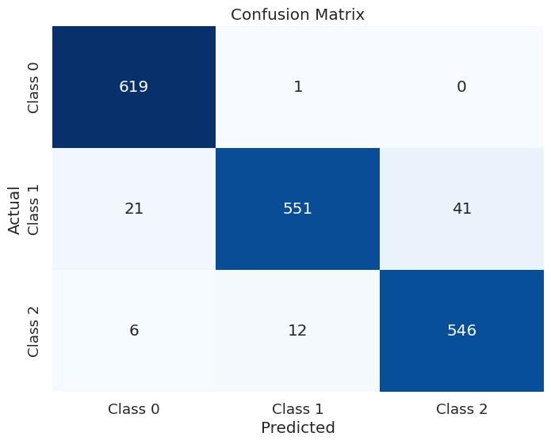

```python
# Compute confusion matrix
cf_mat = confusion_matrix(test_labels, predicted_classes)

# Create a figure and axis
plt.figure(figsize=(8, 6))
sns.set(font_scale=1.2)  # Adjust font size for better readability

# Create a heatmap for the confusion matrix
sns.heatmap(cf_mat, annot=True, fmt='d', cmap='Blues', cbar=False,
            xticklabels=['Class 0', 'Class 1', 'Class 2'],
            yticklabels=['Class 0', 'Class 1', 'Class 2'])

plt.xlabel('Predicted')
plt.ylabel('Actual')
plt.title('Confusion Matrix')
plt.show()
```

## Part 1 - Question 2b - Improved Convolutional Neural Network

This section takes the code from the basic convolutional neural network and applies improvements to improve performance. The commentary will talk over the changes that have been made.

```python
image_data, label_data = load_data('COVID_Mask_Images.pt', 'COVID_Mask_Labels.pt')
```

```python
# Data Preprocessing
train_images, test_images, train_labels, test_labels = train_test_split(image_data, label_data, test_size=0.2, random_state=42)
```

For the model architecture, a large number of changes have been made to increase performance. Firstly, an additional convolutional layer has been added. Secondly, the number of channels in and out has been changed for these layers. Lastly, the kernel size has been increased for each layer from (5,5) to (9,90). A wide range of different changes were tested, including changing the activation functions to tanh or sigmoid. However here the relu activation function seemed to perform best. I also tested different kernel sizes, of (3,3), (5,5), and (7,7). However the kernel size of (9,9) appeared to perform best. As a result, it could be worth testing even higher kernel sizes in the future.

```python
class Conv_NN(nn.Module):
    def __init__(self, n_channels):
        super().__init__()

        #Convolutional and self pooling layers
        self.conv1 = nn.Conv2d(in_channels = n_channels, out_channels = 24, kernel_size = (9,9) )
        self.conv2 = nn.Conv2d(in_channels = 24, out_channels = 48,  kernel_size = (9,9))
        self.conv3 = nn.Conv2d(in_channels = 48, out_channels = 96,  kernel_size = (9,9))
        self.pool = nn.MaxPool2d((2,2))

        # Fully connected layers
        self.fc1 = nn.Linear(96*9*9, 128)
        self.fc2 = nn.Linear(128, 3)

    def forward(self, x):
        x = F.relu(self.conv1(x))
        x = self.pool(x)

        x = F.relu(self.conv2(x))
        x = self.pool(x)

        x = F.relu(self.conv3(x))
        x = self.pool(x)

        # Flatten data for fully connected layers
        x = x.view(-1, 96*9*9)

        #Fully Connected Layer
        x = F.relu(self.fc1(x))
        x = F.log_softmax(self.fc2(x), dim = 1)


        return x
```

```python
conv_net  = Conv_NN(n_channels = 3)
conv_net.to(device)
```

```
Conv_NN(
  (conv1): Conv2d(3, 24, kernel_size=(9, 9), stride=(1, 1))
  (conv2): Conv2d(24, 48, kernel_size=(9, 9), stride=(1, 1))
  (conv3): Conv2d(48, 96, kernel_size=(9, 9), stride=(1, 1))
  (pool): MaxPool2d(kernel_size=(2, 2), stride=(2, 2), padding=0, dilation=1, ceil_mode=False)
  (fc1): Linear(in_features=7776, out_features=128, bias=True)
  (fc2): Linear(in_features=128, out_features=3, bias=True)
)
```

```python
input_images = train_images[0:1].to(device)
test = conv_net.forward(input_images)
test.shape
```

```
torch.Size([1, 3])
```

For the learning algorithm, many of the same improvements have been made as were made to the simple neural network. I found that a learning rate of 0.001 with a batch size of 250 worked well. This time 150 epochs have been used, as that seemed to improve performance slightly more than just using 100 epochs. The nesterov momentum and weight decay have been applied to the SGD here too. The print has been commented out for each epoch to aid readability.

```python
loss_function = nn.CrossEntropyLoss()
optimizer = torch.optim.SGD(conv_net.parameters(), lr=0.001, nesterov=True, momentum=0.9, weight_decay = 1e-3)
```

```python
device = torch.device('cuda:0')
conv_net.to(device)
```

```
Conv_NN(
  (conv1): Conv2d(3, 24, kernel_size=(9, 9), stride=(1, 1))
  (conv2): Conv2d(24, 48, kernel_size=(9, 9), stride=(1, 1))
  (conv3): Conv2d(48, 96, kernel_size=(9, 9), stride=(1, 1))
  (pool): MaxPool2d(kernel_size=(2, 2), stride=(2, 2), padding=0, dilation=1, ceil_mode=False)
  (fc1): Linear(in_features=7776, out_features=128, bias=True)
  (fc2): Linear(in_features=128, out_features=3, bias=True)
)
```

```python
epochs = 150
BATCH_SIZE = 250
for epoch in range (epochs):
    for i in tqdm(range(0,len(train_images), BATCH_SIZE)):
        # Batch Our Data
        batch_data = train_images[i:i+BATCH_SIZE]
        batch_labels = train_labels[i:i+BATCH_SIZE]
        batch_data = batch_data.to(device)
        batch_labels = batch_labels.to(device)

        conv_net.zero_grad()  # sets gradients to 0 before loss calc
        output = conv_net(batch_data)  # pass in the reshaped batch

        loss = loss_function(output, batch_labels)  # calc and grab the loss value
        loss.backward()  # apply this loss backwards through the network's parameters
        optimizer.step()  # attempt to optimize weights to account for loss/gradients

   # print(loss)
```

```python
device = torch.device('cuda:0')
```

```python
with torch.no_grad():
    predicted = conv_net.forward(test_images.to(device))
    print(predicted[0:2], predicted[0:2].shape)


    predicted_classes = torch.argmax(predicted, dim = 1)
    print(predicted_classes[0:5])
    print(test_labels[0:5])


device = torch.device('cpu')
predicted_classes = predicted_classes.to(device)
test_labels = test_labels.to(device)
```

```
tensor([[-9.5367e-07, -1.3857e+01, -3.3482e+01],
        [-3.8953e+01, -1.1989e+01, -6.1989e-06]], device='cuda:0') torch.Size([2, 3])
tensor([0, 2, 1, 2, 1], device='cuda:0')
tensor([0, 2, 1, 2, 1])
```

Evaluating the model performance, the improved convoluted neural network performed with an accuracy of around 97% which is the best performing model yet. This accuracy was fairly robust, fluctuating from around 95%-98% across different runs. This shows that the improvements made to the convolutional neural network have improved the performance.

```python
correct = 0
total = 0
for i in range(len(predicted_classes)):

    if predicted_classes[i] == test_labels[i]:
        correct += 1
    total += 1
print("Accuracy: ", round(correct/total, 3))
```

```
Accuracy:  0.968
```

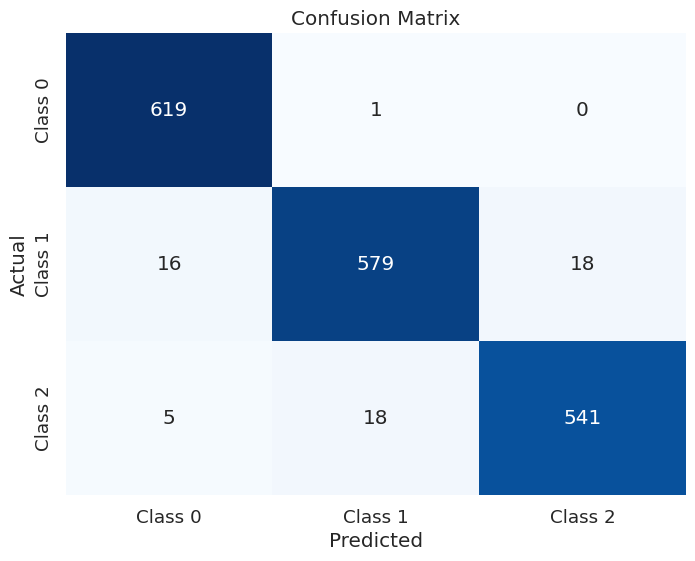

```python
# Compute confusion matrix
cf_mat = confusion_matrix(test_labels, predicted_classes)

# Create a figure and axis
plt.figure(figsize=(8, 6))
sns.set(font_scale=1.2)  # Adjust font size for better readability

# Create a heatmap for the confusion matrix
sns.heatmap(cf_mat, annot=True, fmt='d', cmap='Blues', cbar=False,
            xticklabels=['Class 0', 'Class 1', 'Class 2'],
            yticklabels=['Class 0', 'Class 1', 'Class 2'])

plt.xlabel('Predicted')
plt.ylabel('Actual')
plt.title('Confusion Matrix')
plt.show()
```

## Part 1 - Question 3 - Saving Improved Models

The code below shows the process for saving the models as files, and then uploading those files to the s3 bucket

```python
# Save the model using pickle
model_path = 'simple_neural_network.pkl'
with open(model_path, 'wb') as f:
    pickle.dump(Simple_NN, f)

print("Model saved to", model_path)
```

[output not shown]

```python
# Save the model using pickle
model_path = 'convolutional_neural_network.pkl'
with open(model_path, 'wb') as f:
    pickle.dump(Conv_NN, f)

print("Model saved to", model_path)
```

```
Model saved to convolutional_neural_network.pkl
```

```python
# Upload Models to S3 Bucket:

s3_client = boto3.client('s3')
bucket_name = "harry-parrett-s3-live-bucket"
model_key = f"trained-models/{model_pkl_file}"



s3_client.upload_file('convolutional_neural_network.pkl', bucket_name, model_key)
s3_client.upload_file('simple_neural_network.pkl', bucket_name, model_key)
```

## Part 2 - Learning rates

In this part, two different learning rates are examined. lr = 0.00000001, and lr = 10. The below code retrains the improved convoluted neural network for both of these learning rates. The code is otherwise the same, although only 25 epochs have been used to save time, as that is still enough to clearly see the impact of these learning rates. Discussion about these impacts will be had at the very end of this section

```python
image_data, label_data = load_data('COVID_Mask_Images.pt', 'COVID_Mask_Labels.pt')
train_images, test_images, train_labels, test_labels = train_test_split(image_data, label_data, test_size=0.2, random_state=42)

conv_net  = Conv_NN(n_channels = 3)
device = torch.device('cuda:0')
conv_net.to(device)
```

```
Conv_NN(
  (conv1): Conv2d(3, 24, kernel_size=(9, 9), stride=(1, 1))
  (conv2): Conv2d(24, 48, kernel_size=(9, 9), stride=(1, 1))
  (conv3): Conv2d(48, 96, kernel_size=(9, 9), stride=(1, 1))
  (pool): MaxPool2d(kernel_size=(2, 2), stride=(2, 2), padding=0, dilation=1, ceil_mode=False)
  (fc1): Linear(in_features=7776, out_features=128, bias=True)
  (fc2): Linear(in_features=128, out_features=3, bias=True)
)
```

```python
loss_function = nn.CrossEntropyLoss()
optimizer = torch.optim.SGD(conv_net.parameters(), lr=0.00000001 , nesterov=True, momentum=0.9, weight_decay = 1e-3)
```

```python
epochs = 25
BATCH_SIZE = 250
for epoch in range (epochs):
    for i in tqdm(range(0,len(train_images), BATCH_SIZE)):
        # Batch Our Data
        batch_data = train_images[i:i+BATCH_SIZE]
        batch_labels = train_labels[i:i+BATCH_SIZE]
        batch_data = batch_data.to(device)
        batch_labels = batch_labels.to(device)
        # batch_data.type() Float Tensor


        conv_net.zero_grad()  # sets gradients to 0 before loss calc
        output = conv_net(batch_data)  # pass in the reshaped batch

        loss = loss_function(output, batch_labels)  # calc and grab the loss value
        loss.backward()  # apply this loss backwards through the network's parameters
        optimizer.step()  # attempt to optimize weights to account for loss/gradients

    print(loss)
```

```
tensor(1.1032, device='cuda:0', grad_fn=<NllLossBackward0>)
```

```
tensor(1.1032, device='cuda:0', grad_fn=<NllLossBackward0>)
```

```
tensor(1.1032, device='cuda:0', grad_fn=<NllLossBackward0>)
```

```
tensor(1.1032, device='cuda:0', grad_fn=<NllLossBackward0>)
```

```
tensor(1.1032, device='cuda:0', grad_fn=<NllLossBackward0>)
```

```
tensor(1.1032, device='cuda:0', grad_fn=<NllLossBackward0>)
```

```
tensor(1.1032, device='cuda:0', grad_fn=<NllLossBackward0>)
```

```
tensor(1.1032, device='cuda:0', grad_fn=<NllLossBackward0>)
```

```
tensor(1.1032, device='cuda:0', grad_fn=<NllLossBackward0>)
```

```
tensor(1.1032, device='cuda:0', grad_fn=<NllLossBackward0>)
```

```
tensor(1.1032, device='cuda:0', grad_fn=<NllLossBackward0>)
```

```
tensor(1.1032, device='cuda:0', grad_fn=<NllLossBackward0>)
```

```
tensor(1.1032, device='cuda:0', grad_fn=<NllLossBackward0>)
```

```
tensor(1.1032, device='cuda:0', grad_fn=<NllLossBackward0>)
```

```
tensor(1.1032, device='cuda:0', grad_fn=<NllLossBackward0>)
```

```
tensor(1.1032, device='cuda:0', grad_fn=<NllLossBackward0>)
```

```
tensor(1.1032, device='cuda:0', grad_fn=<NllLossBackward0>)
```

```
tensor(1.1032, device='cuda:0', grad_fn=<NllLossBackward0>)
```

```
tensor(1.1032, device='cuda:0', grad_fn=<NllLossBackward0>)
```

```
tensor(1.1032, device='cuda:0', grad_fn=<NllLossBackward0>)
```

```
tensor(1.1032, device='cuda:0', grad_fn=<NllLossBackward0>)
```

```
tensor(1.1032, device='cuda:0', grad_fn=<NllLossBackward0>)
```

```
tensor(1.1032, device='cuda:0', grad_fn=<NllLossBackward0>)
```

```
tensor(1.1032, device='cuda:0', grad_fn=<NllLossBackward0>)
```

```
tensor(1.1032, device='cuda:0', grad_fn=<NllLossBackward0>)
```

```python
with torch.no_grad():
    predicted = conv_net.forward(test_images.to(device))
    print(predicted[0:2], predicted[0:2].shape)


    predicted_classes = torch.argmax(predicted, dim = 1)

device = torch.device('cpu')
predicted_classes = predicted_classes.to(device)
test_labels = test_labels.to(device)

correct = 0
total = 0
for i in range(len(predicted_classes)):

    if predicted_classes[i] == test_labels[i]:
        correct += 1
    total += 1
print("Accuracy: ", round(correct/total, 3))
```

```
tensor([[-1.1349, -1.0417, -1.1218],
        [-1.1277, -1.0483, -1.1218]], device='cuda:0') torch.Size([2, 3])
Accuracy:  0.341
```

```python
image_data, label_data = load_data('COVID_Mask_Images.pt', 'COVID_Mask_Labels.pt')
train_images, test_images, train_labels, test_labels = train_test_split(image_data, label_data, test_size=0.2, random_state=42)

conv_net  = Conv_NN(n_channels = 3)
device = torch.device('cuda:0')
conv_net.to(device)
```

```
Conv_NN(
  (conv1): Conv2d(3, 24, kernel_size=(9, 9), stride=(1, 1))
  (conv2): Conv2d(24, 48, kernel_size=(9, 9), stride=(1, 1))
  (conv3): Conv2d(48, 96, kernel_size=(9, 9), stride=(1, 1))
  (pool): MaxPool2d(kernel_size=(2, 2), stride=(2, 2), padding=0, dilation=1, ceil_mode=False)
  (fc1): Linear(in_features=7776, out_features=128, bias=True)
  (fc2): Linear(in_features=128, out_features=3, bias=True)
)
```

```python
loss_function = nn.CrossEntropyLoss()
optimizer = torch.optim.SGD(conv_net.parameters(), lr=10 , nesterov=True, momentum=0.9, weight_decay = 1e-3)
```

```python
epochs = 25
BATCH_SIZE = 250
for epoch in range (epochs):
    for i in tqdm(range(0,len(train_images), BATCH_SIZE)):
        # Batch Our Data
        batch_data = train_images[i:i+BATCH_SIZE]
        batch_labels = train_labels[i:i+BATCH_SIZE]
        batch_data = batch_data.to(device)
        batch_labels = batch_labels.to(device)
        # batch_data.type() Float Tensor


        conv_net.zero_grad()  # sets gradients to 0 before loss calc
        output = conv_net(batch_data)  # pass in the reshaped batch

        loss = loss_function(output, batch_labels)  # calc and grab the loss value
        loss.backward()  # apply this loss backwards through the network's parameters
        optimizer.step()  # attempt to optimize weights to account for loss/gradients

    print(loss)
```

```
tensor(5.5657, device='cuda:0', grad_fn=<NllLossBackward0>)
```

```
tensor(nan, device='cuda:0', grad_fn=<NllLossBackward0>)
```

```
tensor(nan, device='cuda:0', grad_fn=<NllLossBackward0>)
```

```
tensor(nan, device='cuda:0', grad_fn=<NllLossBackward0>)
```

```
tensor(nan, device='cuda:0', grad_fn=<NllLossBackward0>)
```

```
tensor(nan, device='cuda:0', grad_fn=<NllLossBackward0>)
```

```
tensor(nan, device='cuda:0', grad_fn=<NllLossBackward0>)
```

```
tensor(nan, device='cuda:0', grad_fn=<NllLossBackward0>)
```

```
tensor(nan, device='cuda:0', grad_fn=<NllLossBackward0>)
```

```
tensor(nan, device='cuda:0', grad_fn=<NllLossBackward0>)
```

```
tensor(nan, device='cuda:0', grad_fn=<NllLossBackward0>)
```

```
tensor(nan, device='cuda:0', grad_fn=<NllLossBackward0>)
```

```
tensor(nan, device='cuda:0', grad_fn=<NllLossBackward0>)
```

```
tensor(nan, device='cuda:0', grad_fn=<NllLossBackward0>)
```

```
tensor(nan, device='cuda:0', grad_fn=<NllLossBackward0>)
```

```
tensor(nan, device='cuda:0', grad_fn=<NllLossBackward0>)
```

```
tensor(nan, device='cuda:0', grad_fn=<NllLossBackward0>)
```

```
tensor(nan, device='cuda:0', grad_fn=<NllLossBackward0>)
```

```
tensor(nan, device='cuda:0', grad_fn=<NllLossBackward0>)
```

```
tensor(nan, device='cuda:0', grad_fn=<NllLossBackward0>)
```

```
tensor(nan, device='cuda:0', grad_fn=<NllLossBackward0>)
```

```
tensor(nan, device='cuda:0', grad_fn=<NllLossBackward0>)
```

```
tensor(nan, device='cuda:0', grad_fn=<NllLossBackward0>)
```

```
tensor(nan, device='cuda:0', grad_fn=<NllLossBackward0>)
```

```
tensor(nan, device='cuda:0', grad_fn=<NllLossBackward0>)
```

```python
with torch.no_grad():
    predicted = conv_net.forward(test_images.to(device))
    print(predicted[0:2], predicted[0:2].shape)


    predicted_classes = torch.argmax(predicted, dim = 1)

device = torch.device('cpu')
predicted_classes = predicted_classes.to(device)
test_labels = test_labels.to(device)

correct = 0
total = 0
for i in range(len(predicted_classes)):

    if predicted_classes[i] == test_labels[i]:
        correct += 1
    total += 1
print("Accuracy: ", round(correct/total, 3))
```

```
tensor([[nan, nan, nan],
        [nan, nan, nan]], device='cuda:0') torch.Size([2, 3])
Accuracy:  0.345
```

Looking at both learning rates, their impacts can clearly be seen. For the very low learning rate, the error doesnt change across all 25 epochs. The steps that are being taken are too small so the model is not able to learn quickly enough to be effective. This is clearly seen in the accuracy, with an accuracy of 34% essentially being as good as guessing for a classification problem with 3 classes. For the very high learning rate, the loss very quickly diverges to infinity and remains there, hence the error value showing as nan for all subsequent epochs. This is also shown in the accuracy, with an accuracy of 35%.

There are advantages and disadvantages to having a higher or lower learning rate. A low learning rate has very slow convergence, which allows for greater fine tuning as the model takes smaller steps towards an optimal solution. However, this leads to slower optimisation with greater training times, and a greater risk of getting stuck in local minima if the model is taking too small steps to escape. A high learning rate means that initial convergence can occur more rapidly, making training times shorter. A high learning rate is also better at escaping local minima, by taking large enough steps. However, a high learning rate has a greater risk of a highly fluctuating loss function, as well as overshooting optimal values by taking steps that are too large. Therefore, selecting an appropriate learning rate is very important, and will be different for every dataset. The ideal learning rate is one high enough to quickly find the optimal value, but small enough to fine tune the model.

## Part 2 - Batch Size

Batch size refers to the number of training examples used for each iteration of the optimisation process. There are advantages and disadvantages associated with a higher and a lower batch size. For a higher batch size, the main disadvantage is that too large of a batch size leads to poor generalisation. A higher batch size also leads to slower convergence. However, the main advantage of a high batch size is that the convergence is more likely to converge to the global optima, with a batch size equal to the entire dataset guaranteeing this.

On the other hand, a smaller batch size has faster convergence towards good solutions, as the model can begin learning on a smaller amount of the data. The main downside of a smaller batch size is that the model might not be able to converge to the global optima.

Therefore it can often be benefitial to start at a small batch size to take advantage of the additional speed, before gradually increasing the batch size throughout training to get the benefits of converging towards the global optima.